# Normal distribution

Nima Rafati

# Question

The statements has two parts:  
1- Confidence interval of the POPULATION mean annual income is 50000-80000.  
2- The probability of the population mean to be within this range is 95%.

# Normal distribution

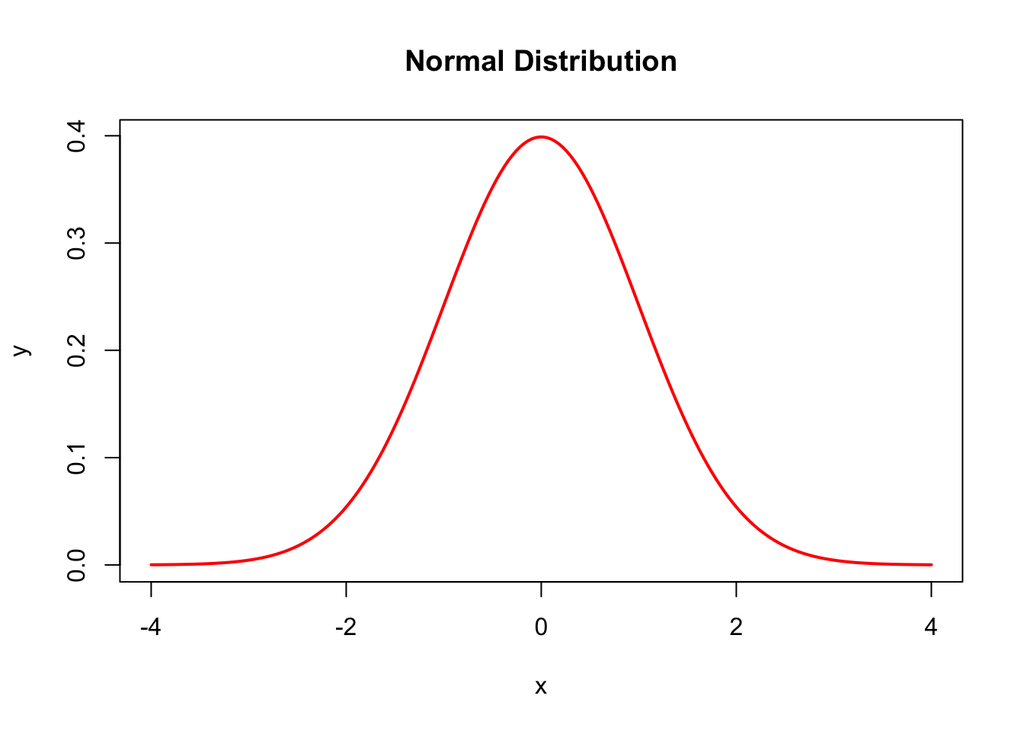

```r
x=seq(-4,4,length=200)
y=1/sqrt(2*pi)*exp(-x^2/2)
plot(x,y,type="l",lwd=2,col="red", main="Normal Distribution")
```

With 95% CI of the mean is calculated by :

$\overline{x} \pm Z \frac{\sigma}{\sqrt{N}}$

Covering this part of the distribution.

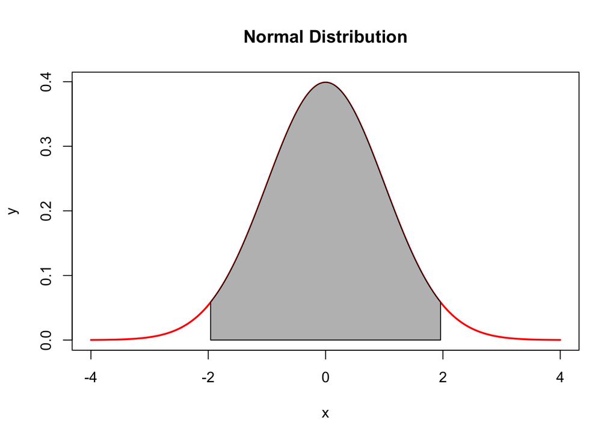

```r
x=seq(-4,4,length=200)
y=1/sqrt(2*pi)*exp(-x^2/2)
plot(x,y,type="l",lwd=2,col="red", main="Normal Distribution")
x=seq(-1.96,1.96,length=200)
y=dnorm(x)
polygon(c(-1.96,x,1.96),c(0,y,0),col="gray")
```

So considering the hypothetical population that you have (100 individuals) two parameters are calculated: mean and sd. Then we calculate confidence interval using above formula by choosing corresponding Z value. The interval indicates how much uncertainty we have in our estimation from a true parameter (mean). The narrower the interval the more reliable estimates we have. Thus it does not mean there is a 95% probability that the (true) parameter (mean) is within the range. Estimated mean annual income for AN INDIVIDUAL may or may not contain true mean. In other words, in 100 randomly selected individuals 95 of them will have mean annual income within this range.